# Spotify’s Top Tracks of 2017

By Brittany Chiang

Data Set: [Spotify’s Top Tracks of 2017](https://open.spotify.com/user/spotify/playlist/37i9dQZF1DX7Axsg3uaDZb?si=nlWdcezESwCW5HazmIGi8A)

# Data Acquisition

## Acquisition from API (8 points)

```r
library(devtools)
library(stringdist)
devtools::install_github('charlie86/spotifyr')
library(spotifyr)
# Set client ID
Sys.setenv(SPOTIFY_CLIENT_ID = "7cd7c410d1a94e06b4a81e4bda235aa5")
# Set client ID
Sys.setenv(SPOTIFY_CLIENT_SECRET = "d11a4598b7ff4b97b055ba53cfc72606")
# Get access token
access_token <- get_spotify_access_token()
playlist_username <- 'spotify'
playlist_uris <- c("37i9dQZF1DX7Axsg3uaDZb")
raw_data <- get_playlist_audio_features('spotify', playlist_uris)
```

## Acquisition from a file (4 points)

```r
# write raw data to CSV
write.csv(raw_data, "top2017playlist.csv")
# pull in data from CSV and store in top2017 data frame
top2017 <- read.csv("top2017playlist.csv", header = TRUE, sep = ",")
```

# Data Exploration

```r
library(dplyr)
glimpse(top2017)
```

```
Observations: 100
Variables: 30
$ X                      <int> 1, 2, 3, 4, 5, 6, 7, 8, 9, 10, 11, 12, 13, 14, 15, 16, 17, 18, 19, 20, 21, 22, 23, 24, 25, 26, ...
$ playlist_name          <fct> Top Tracks of 2017: USA, Top Tracks of 2017: USA, Top Tracks of 2017: USA, Top Tracks of 2017: ...
$ playlist_uri           <fct> 37i9dQZF1DX7Axsg3uaDZb, 37i9dQZF1DX7Axsg3uaDZb, 37i9dQZF1DX7Axsg3uaDZb, 37i9dQZF1DX7Axsg3uaDZb,...
$ playlist_tracks_url    <fct> https://api.spotify.com/v1/users/spotify/playlists/37i9dQZF1DX7Axsg3uaDZb/tracks?offset=0&limit...
$ playlist_num_tracks    <int> 100, 100, 100, 100, 100, 100, 100, 100, 100, 100, 100, 100, 100, 100, 100, 100, 100, 100, 100, ...
$ snapshot_id            <fct> 1SitYj19tsmdftC5NY8zXM8o+yrsOOS0Cm8ijUG2kIj7PCW8xsbR848Aecz4H/qb6/ZN2jRgCzI=, 1SitYj19tsmdftC5N...
$ playlist_img           <fct> https://i.scdn.co/image/e45f2ca5b6c1ad7f332d7b74432f697d94e96d05, https://i.scdn.co/image/e45f2...
$ track_name             <fct> HUMBLE., XO TOUR Llif3, Shape of You, Congratulations, Despacito - Remix, Mask Off, iSpy (feat....
$ track_uri              <fct> 7KXjTSCq5nL1LoYtL7XAwS, 7GX5flRQZVHRAGd6B4TmDO, 7qiZfU4dY1lWllzX7mPBI3, 3a1lNhkSLSkpJE4MSHpDu9,...
$ artist_name            <fct> Kendrick Lamar, Lil Uzi Vert, Ed Sheeran, Post Malone, Luis Fonsi, Future, KYLE, Khalid, Bruno ...
$ album_name             <fct> DAMN., Luv Is Rage 2, ÷ (Deluxe), Stoney (Deluxe), Despacito Feat. Justin Bieber (Remix), FUTUR...
$ album_img              <fct> https://i.scdn.co/image/661e1a935e2eacdd45c05ef618565535e7bed2ad, https://i.scdn.co/image/0ea85...
$ track_added_at         <fct> 2017-12-05 07:25:55, 2017-12-05 07:25:55, 2017-12-05 07:25:55, 2017-12-05 07:25:55, 2017-12-05 ...
```

[output cut: 17 more lines]

# Data Cleaning & Shaping

## Parsing of text (4 points)

Removing some unnecessary columns from the data frame to make the data set easier to parse and work with

```r
top2017 <- subset(top2017, select = -c(playlist_name, playlist_uri, playlist_tracks_url, playlist_num_tracks, snapshot_id, playlist_img, track_uri, album_img, track_added_at, track_preview_url, track_open_spotify_url))
```

## Check for any missing values in the data set

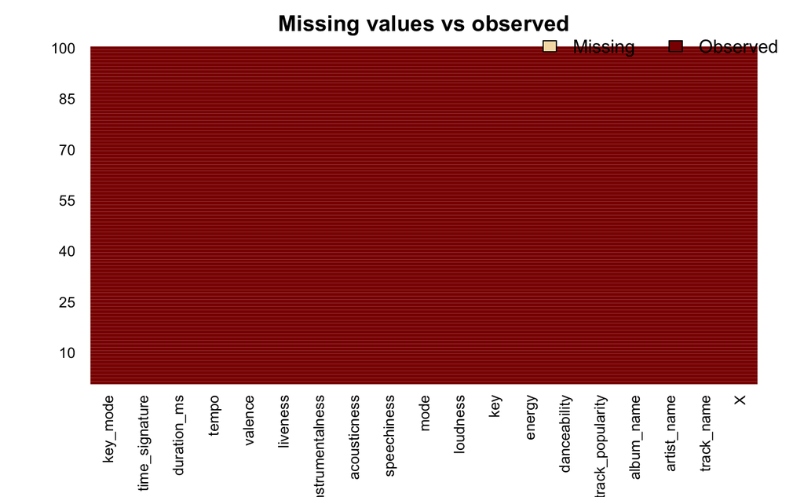

```r
library(Amelia)
missmap(top2017, main = "Missing values vs observed")
```

This is a pretty small and clean data set, and there’s no missing values out of the 100 tracks in this playlist.

## Normalization/standardization of feature values (4 points)

```r
# convert milliseconds to seconds
top2017$duration_ms <- round(top2017$duration_ms / 1000)
# rename column from 'duration_ms' to just 'duration'
colnames(top2017)[17] <- "duration"
# change loudness from negative to positive values since quantitatively the smaller the loudness value louder a song is
top2017$loudness <- - top2017$loudness
# change name of first column to "rank"
colnames(top2017)[1] <- "rank"
```

## Exploratory Data Plots (5 points)

Full description of audio features: https://developer.spotify.com/web-api/get-several-audio-features/

```r
library(ggplot2)
# Set ggplot theme
theme_set(theme_bw())
```

## Detection of Outliers (5 points)

```r
# Gets outliers for a given column (outliers are 2 standard deviations from the mean)
# Args: column (vector)
# Returns the rows of the data frame that are outliers for the given column
getOutliers <- function(column) {
  return (top2017[(abs(column - mean(column)) / sd(column)) > 2,])
}
```

#### Artists with more than one track in the top 100 playlist

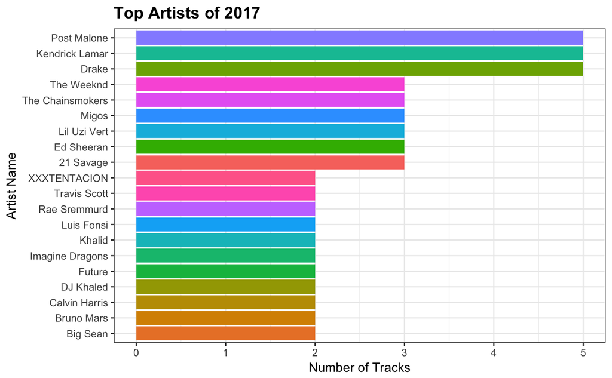

```r
# group together artists
top_artists <- group_by(top2017, artist_name)
top_artists <- summarise(top_artists, count = n())
top_artists <- arrange(top_artists, desc(count))
top_artists <- filter(top_artists, count > 1)
ggplot(top_artists, aes(x = reorder(artist_name,count), y = count)) +
  geom_bar(aes(y = count, fill = artist_name), stat = "identity") +
  coord_flip() +
  labs(x = "Artist Name", y = "Number of Tracks", title = "Top Artists of 2017") +
  theme(legend.position = "none", plot.title = element_text(size = 14, face = "bold"))
```

**Conclusion:** Post Malone, Kendrick Lamar, and Drake were the top artists of 2017

### Danceability

Describes how suitable a track is for dancing based on a combination of musical elements including tempo, rhythm stability, beat strength, and overall regularity. A value of 0.0 is least danceable and 1.0 is most danceable.

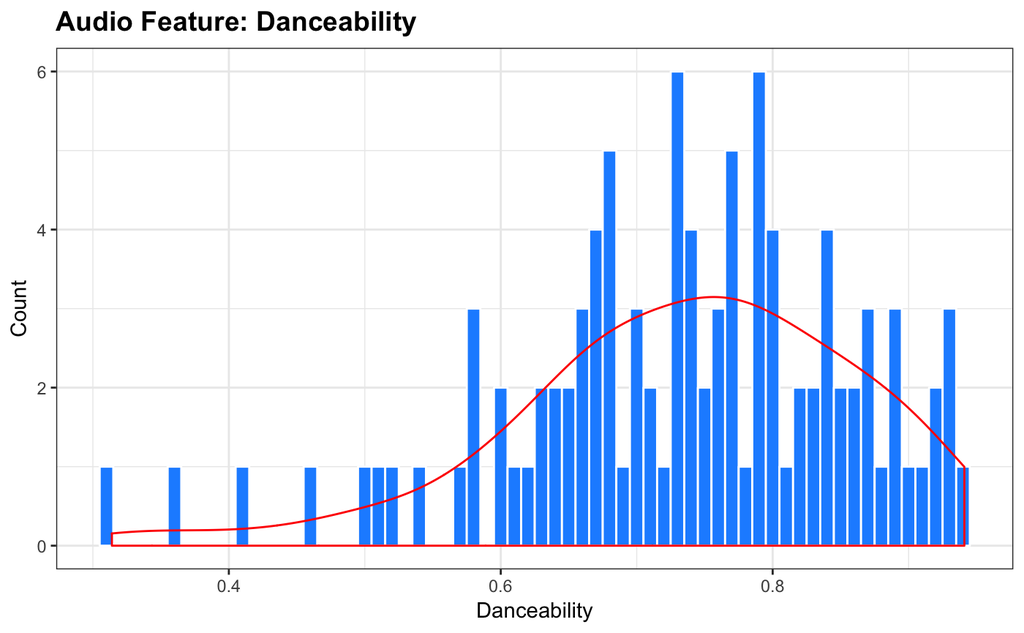

```r
danceability <- top2017$danceability
ggplot(data=top2017, aes(danceability)) +
  geom_histogram(fill = "dodgerblue", col = I("white"), binwidth = 0.01) +
  labs(title = "Audio Feature: Danceability") +
  labs(x = "Danceability", y = "Count") +
  theme(plot.title = element_text(size = 14, face = "bold")) +
  geom_density(col = 2)
```

```r
cat("Mean value of danceability: ", mean(danceability))
```

```
Mean value of danceability:  0.73355
```

```r
cat("Number of danceability outliers: ", nrow(getOutliers(danceability)))
```

```
Number of danceability outliers:  4
```

### Energy

A measure from 0.0 to 1.0 and represents a perceptual measure of intensity and activity. Typically, energetic tracks feel fast, loud, and noisy. For example, death metal has high energy, while a Bach prelude scores low on the scale. Perceptual features contributing to this attribute include dynamic range, perceived loudness, timbre, onset rate, and general entropy.

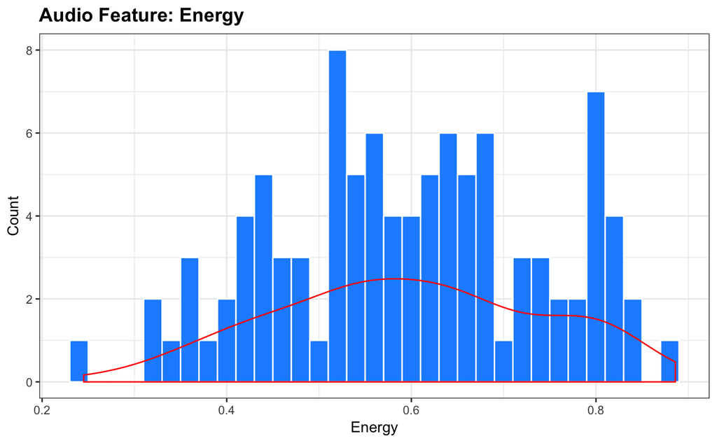

```r
energy <- top2017$energy
ggplot(data=top2017, aes(energy)) +
  geom_histogram(fill = "dodgerblue", col = I("white"), binwidth = 0.02) +
  labs(title = "Audio Feature: Energy") +
  labs(x = "Energy", y = "Count") +
  theme(plot.title = element_text(size = 14, face = "bold")) +
  geom_density(col = 2)
```

```r
cat("Mean value of energy: ", mean(energy))
```

```
Mean value of energy:  0.59642
```

```r
cat("Number of energy outliers: ", nrow(getOutliers(energy)))
```

```
Number of energy outliers:  2
```

**Conclusion:** The distribution of the energy of the top 100 tracks was relatively well dispersed, but mostly mid-to-high energy

### Keys of Top Songs

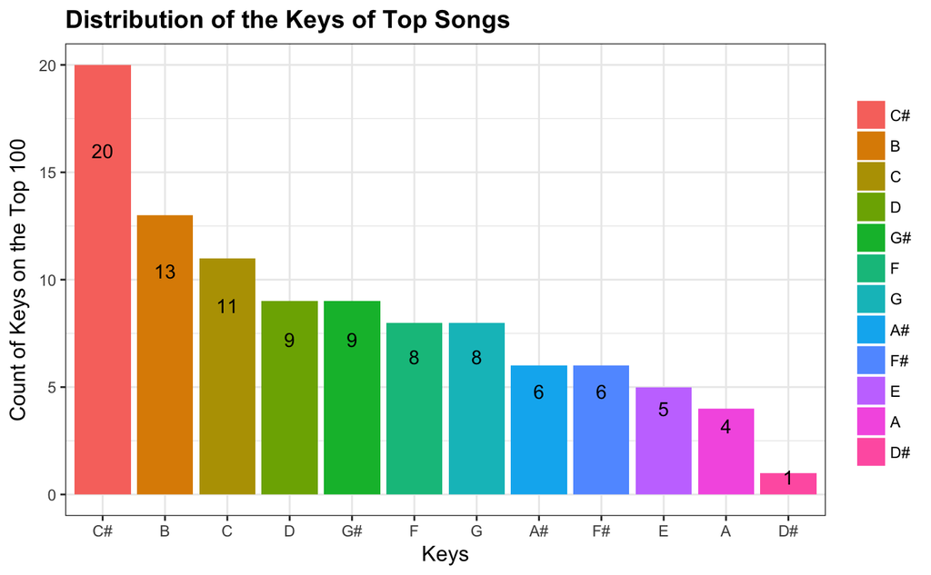

```r
song_keys <- top2017 %>%
  group_by(key) %>%
  summarise(n_key = n()) %>%
  arrange(desc(n_key))

song_keys$key <- factor(song_keys$key, levels = song_keys$key[order(song_keys$n_key)])
ggplot(song_keys, aes(x = reorder(key,-n_key), y = n_key, fill = reorder(key,-n_key))) +
  geom_bar(stat = "identity") +
  labs(title = "Distribution of the Keys of Top Songs", x = "Keys", y = "Count of Keys on the Top 100") +
  geom_text(aes(label = n_key), position = position_stack(vjust = 0.8)) +
  theme(plot.title = element_text(size = 14, face = "bold"), axis.title = element_text(size=12)) +
  theme(legend.title = element_blank())
```

**Conclusion:** The most common key among the top 100 tracks of 2017 was C# (which is surprising!)

### Loudness

The overall loudness of a track in decibels (dB). Loudness values are averaged across the entire track and are useful for comparing relative loudness of tracks. Loudness is the quality of a sound that is the primary psychological correlate of physical strength (amplitude). Values typical range between -60 and 0 db.

Note: I’ve inverted the loudness values from negative to positive

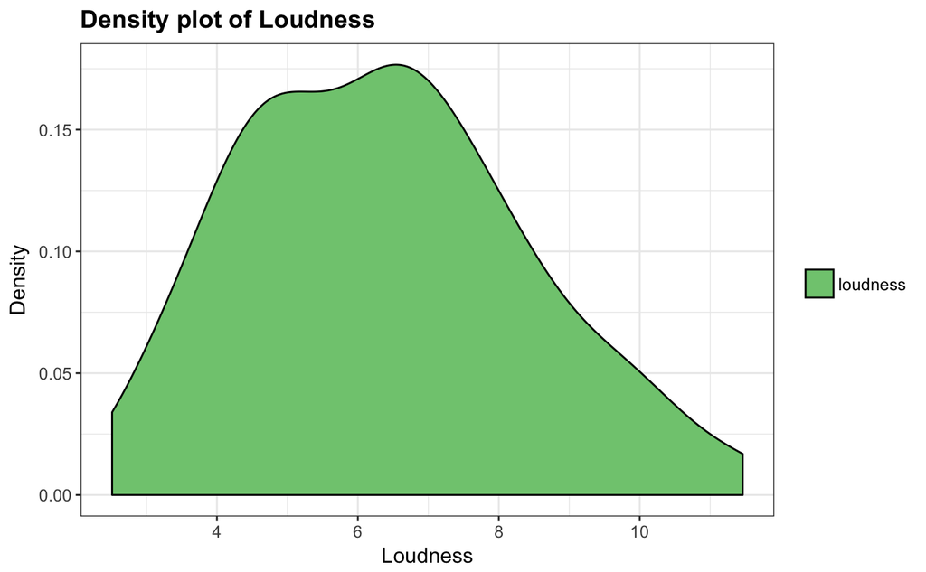

```r
loudness <- top2017$loudness
ggplot(top2017) +
  geom_density(aes(loudness, fill = "loudness")) +
  scale_x_continuous(name = "Loudness") +
  scale_y_continuous(name = "Density") +
  ggtitle("Density plot of Loudness") +
  theme(plot.title = element_text(size = 14, face = "bold"),
        text = element_text(size = 12)) +
  theme(legend.title = element_blank()) +
  scale_fill_brewer(palette = "Accent")
```

```r
cat("Mean value of loudness: ", mean(loudness))
```

```
Mean value of loudness:  6.37808
```

```r
cat("Number of loudness outliers: ", nrow(getOutliers(loudness)))
```

```
Number of loudness outliers:  2
```

**Conclusion:** The Top 100 Songs are mostly not so loud.

### Mode

Indicates the modality (major or minor) of a track, the type of scale from which its melodic content is derived. Major is represented by 1 and minor is 0.

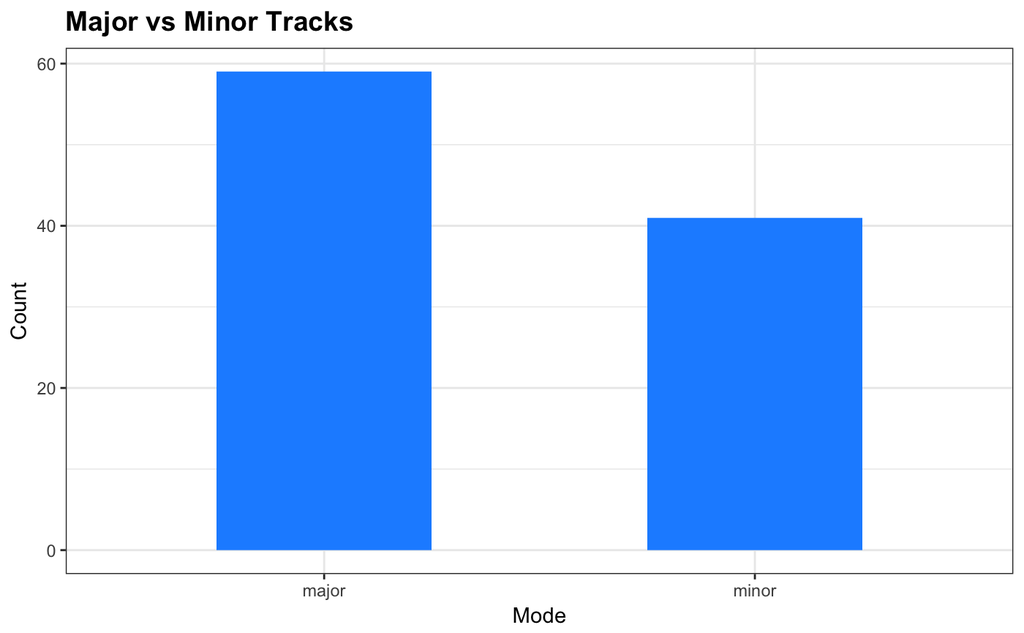

```r
ggplot(data=top2017, aes(top2017$mode, ..count..)) +
  geom_bar(stat = "count", fill = "dodgerblue", width=0.5) +
  labs(title = "Major vs Minor Tracks") +
  labs(x = "Mode", y = "Count") +
  theme(plot.title = element_text(size = 14, face = "bold"))
```

**Conclusion:** Major key tracks are preferred over minor key tracks. This is expected, since major key sounds happier than minor key.

### Speechiness

Detects the presence of spoken words in a track. The more exclusively speech-like the recording (e.g. talk show, audio book, poetry), the closer to 1.0 the attribute value.

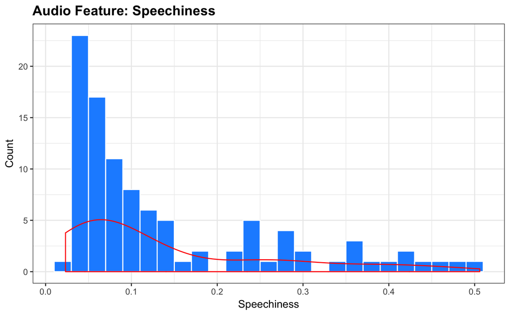

```r
speechiness <- top2017$speechiness
ggplot(data=top2017, aes(speechiness)) +
  geom_histogram(fill = "dodgerblue", col = I("white"), binwidth = 0.02) +
  labs(title = "Audio Feature: Speechiness") +
  labs(x = "Speechiness", y = "Count") +
  theme(plot.title = element_text(size = 14, face = "bold")) +
  geom_density(col = 2)
```

```r
cat("Mean value of speechiness: ", mean(speechiness))
```

```
Mean value of speechiness:  0.14121
```

```r
cat("Number of speechiness outliers: ", nrow(getOutliers(speechiness)))
```

```
Number of speechiness outliers:  7
```

**Conclusion:** The top 100 tracks of 2017 did not contain many spoken words

### Acousticness

A confidence measure from 0.0 to 1.0 of whether the track is acoustic. 1.0 represents high confidence the track is acoustic.

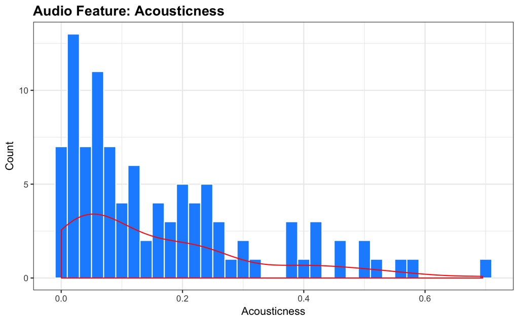

```r
acousticness <- top2017$acousticness
ggplot(data=top2017, aes(acousticness)) +
  geom_histogram(fill = "dodgerblue", col = I("white"), binwidth = 0.02) +
  labs(title = "Audio Feature: Acousticness") +
  labs(x = "Acousticness", y = "Count") +
  theme(plot.title = element_text(size = 14, face = "bold")) +
  geom_density(col = 2)
```

```r
cat("Mean value of acousticness: ", mean(acousticness))
```

```
Mean value of acousticness:  0.1652052
```

```r
cat("Number of acousticness outliers: ", nrow(getOutliers(acousticness)))
```

```
Number of acousticness outliers:  6
```

**Conclusion:** The top 100 tracks of 2017 were mostly not very acoustic. People don’t stream acoustic songs as much as non-acoustic ones.

### Liveness

Detects the presence of an audience in the recording. Higher liveness values represent an increased probability that the track was performed live. A value above 0.8 provides strong likelihood that the track is live.

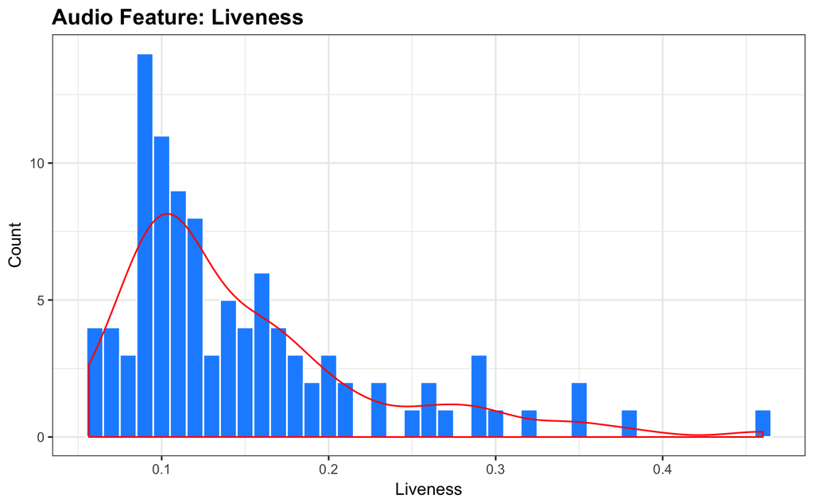

```r
liveness <- top2017$liveness
ggplot(data=top2017, aes(liveness)) +
  geom_histogram(fill = "dodgerblue", col = I("white"), binwidth = 0.01) +
  labs(title = "Audio Feature: Liveness") +
  labs(x = "Liveness", y = "Count") +
  theme(plot.title = element_text(size = 14, face = "bold")) +
  geom_density(col = 2)
```

```r
cat("Mean value of liveness: ", mean(liveness))
```

```
Mean value of liveness:  0.14947
```

```r
cat("Number of liveness outliers: ", nrow(getOutliers(liveness)))
```

```
Number of liveness outliers:  5
```

**Conclusion:** As expected, the mean value of liveness was very low, at 0.15. People go to concerts to listen to live music, not spotify.

### Valence

A measure from 0.0 to 1.0 describing the musical positiveness conveyed by a track. Tracks with high valence sound more positive (e.g. happy, cheerful, euphoric), while tracks with low valence sound more negative (e.g. sad, depressed, angry).

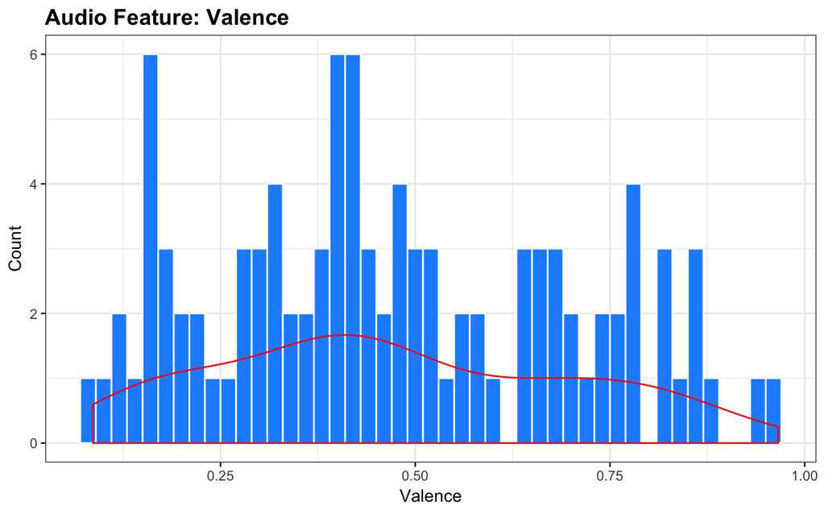

```r
valence <- top2017$valence
ggplot(data=top2017, aes(valence)) +
  geom_histogram(fill = "dodgerblue", col = I("white"), binwidth = 0.02) +
  labs(title = "Audio Feature: Valence") +
  labs(x = "Valence", y = "Count") +
  theme(plot.title = element_text(size = 14, face = "bold")) +
  geom_density(col = 2)
```

```r
cat("Mean value of valence: ", mean(valence))
```

```
Mean value of valence:  0.473075
```

```r
cat("Number of valence outliers: ", nrow(getOutliers(valence)))
```

```
Number of valence outliers:  2
```

**Conclusion:** Happy and sad songs are actually pretty normally distributed at 0.473. The distribution of happy and sad songs is pretty even.

### Tempo

The overall estimated tempo of a track in beats per minute (BPM). In musical terminology, tempo is the speed or pace of a given piece and derives directly from the average beat duration.

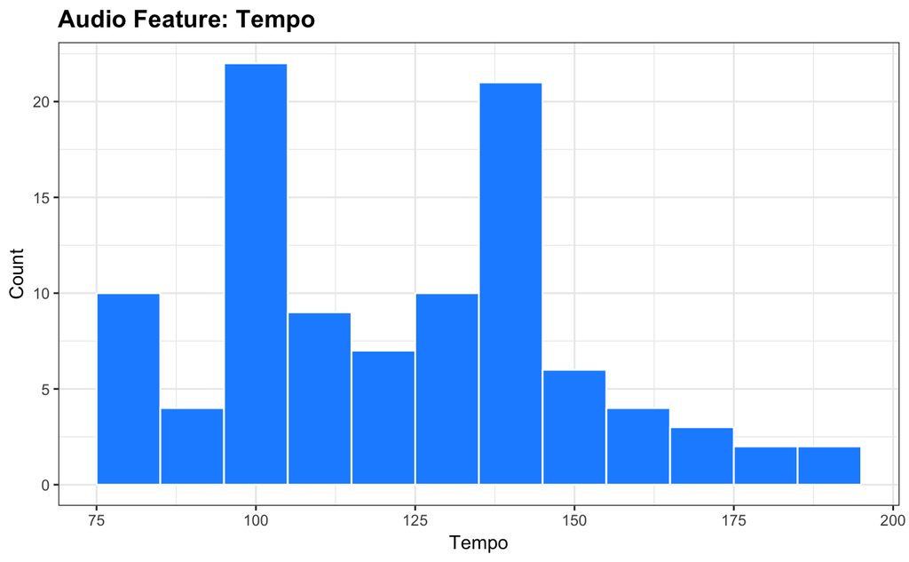

```r
tempo <- as.numeric(as.character(top2017$tempo))
ggplot(data=top2017, aes(tempo)) +
  geom_histogram(fill = "dodgerblue", col = I("white"), binwidth = 10) +
  labs(title = "Audio Feature: Tempo") +
  labs(x = "Tempo", y = "Count") +
  theme(plot.title = element_text(size = 14, face = "bold"))
```

```r
cat("Mean value of tempo: ", mean(tempo))
```

```
Mean value of tempo:  121.61
```

```r
cat("Number of tempo outliers: ", nrow(getOutliers(tempo)))
```

```
Number of tempo outliers:  4
```

**Conclusion:** The most popular tempo of a track generally ranges between 100 BPM And 150 BPM.

[Tempo Markings](https://en.wikipedia.org/wiki/Tempo)

- Grave – very slow (25–45 bpm)
- Largo – broadly (40–60 bpm)
- Larghetto – rather broadly (60–66 bpm)
- Adagio – slowly with great expression (66–76 bpm)
- Andante – at a walking pace (76–108 bpm)
- Moderato – at a moderate speed (108–120 bpm)
- Allegro – fast, quickly, and bright (120–156 bpm)
- Vivace – lively and fast (156–176 bpm)
- Presto – very, very fast (176–200 bpm)
- Prestissimo – even faster than presto (200 bpm and over)

## Feature engineering: new derived features (4 points)

```r
# add a new column called tempo_marking based on grouping above
assignTempoMarking <- function(x) {
  tempo <- as.numeric(as.character(x['tempo']))

  if (tempo > 25 & tempo < 45) {
    return("grave")
  } else if (tempo > 40 & tempo < 60) {
    return("largo")
  } else if (tempo > 60 & tempo < 66) {
    return("larghetto")
  } else if (tempo > 66 & tempo < 76) {
    return("adagio")
  } else if (tempo > 76 & tempo < 108) {
    return("andante")
  } else if (tempo > 108 & tempo < 120) {
    return("moderato")
  } else if (tempo > 120 & tempo < 156) {
    return("allegro")
  } else if (tempo > 156 & tempo < 176) {
    return("vivace")
  } else if (tempo > 176 & tempo < 200) {
    return("presto")
  } else if (tempo > 200) {
    return("prestissimo")
  }
}
top2017$tempo_marking <- apply(top2017, 1, assignTempoMarking)
```

Group tempo markings together to plot

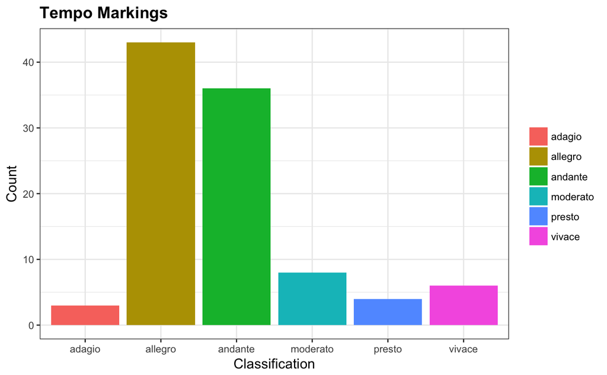

```r
# group tempo markings
markings <- top2017 %>%
  group_by(tempo_marking) %>%
  summarise(n_marking = n()) %>%
  arrange(desc(n_marking))
ggplot(markings, aes(x = tempo_marking, y = n_marking, fill = tempo_marking)) +
  geom_bar(stat = "identity") +
  labs(title = "Tempo Markings", x = "Classification", y = "Count") +
  theme(plot.title = element_text(size = 14, face = "bold"), axis.title = element_text(size=12)) +
  theme(legend.title = element_blank())
```

**Conclusion:** The most popular tempo classifications were allegro and andante (76-156 BPM)

### Duration (in seconds)

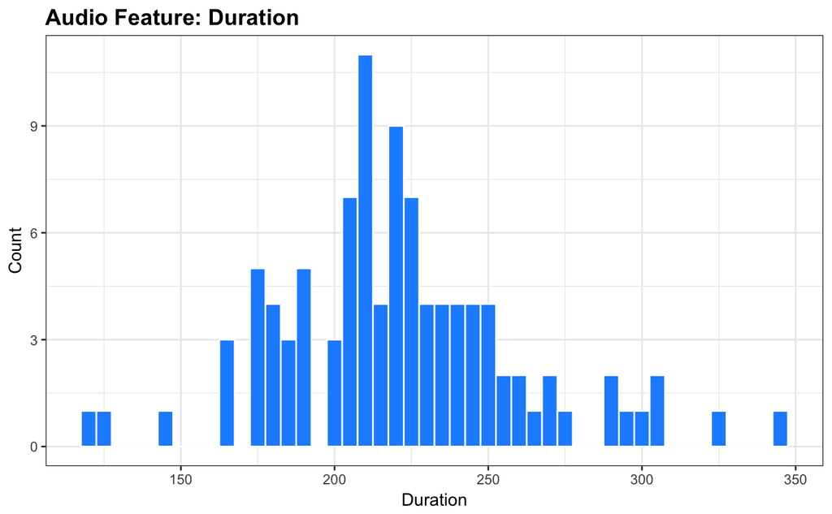

```r
duration <- top2017$duration
ggplot(data=top2017, aes(duration)) +
  geom_histogram(fill = "dodgerblue", col = I("white"), binwidth = 5) +
  labs(title = "Audio Feature: Duration") +
  labs(x = "Duration", y = "Count") +
  theme(plot.title = element_text(size = 14, face = "bold"))
```

```r
cat("Mean value of duration: ", mean(duration))
```

```
Mean value of duration:  221.03
```

```r
cat("Number of duration outliers: ", nrow(getOutliers(duration)))
```

```
Number of duration outliers:  8
```

**Conclusion:** The mean duration of the top 100 tracks is 221 seconds, which is about 3 minutes and 41 seconds (3:41). People don’t like songs that are too long.

### Time Signature

An estimated overall time signature of a track. The time signature (meter) is a notational convention to specify how many beats are in each bar (or measure).

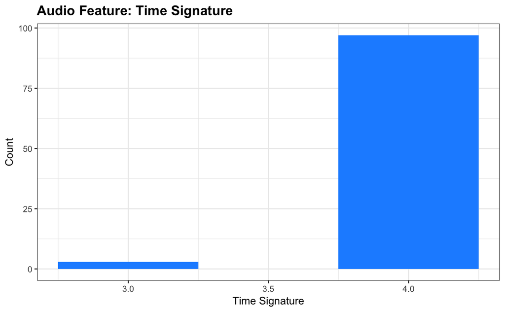

```r
time_signature <- top2017$time_signature
ggplot(data=top2017, aes(time_signature, ..count..)) +
  geom_bar(stat = "count", fill = "dodgerblue", width = 0.5) +
  labs(title = "Audio Feature: Time Signature") +
  labs(x = "Time Signature", y = "Count") +
  theme(plot.title = element_text(size = 14, face = "bold"))
```

```r
cat("Mean value of time signature: ", mean(time_signature))
```

```
Mean value of time signature:  3.97
```

```r
cat("Number of time signature outliers: ", nrow(getOutliers(time_signature)))
```

```
Number of time signature outliers:  3
```

**Conclusion:** The majority of top 100 tracks are in a 4/4 time signature.

#### Min-Max Normalization

```r
top2017numeric <- subset(top2017, select = -c(rank, track_name, artist_name, album_name, key, mode, time_signature, key_mode, tempo_marking))
# min max normalization for factors not already scaled from 0 to 1
minmax <- function(x) {
  (x - min(x)) / (max(x) - min(x))
}
top2017$track_popularity <- minmax(top2017numeric$track_popularity)
top2017$loudness <- minmax(top2017numeric$loudness)
top2017$tempo <- minmax(top2017numeric$tempo)
top2017$duration <- minmax(top2017numeric$duration)
top2017numeric$track_popularity <- minmax(top2017numeric$track_popularity)
top2017numeric$loudness <- minmax(top2017numeric$loudness)
top2017numeric$tempo <- minmax(top2017numeric$tempo)
top2017numeric$duration <- minmax(top2017numeric$duration)
```

## Correlation/collinearity analysis (5 points)

In order to understand the correlation between variables, I’ll use corrplot function, which is one of the base data visualization functions.

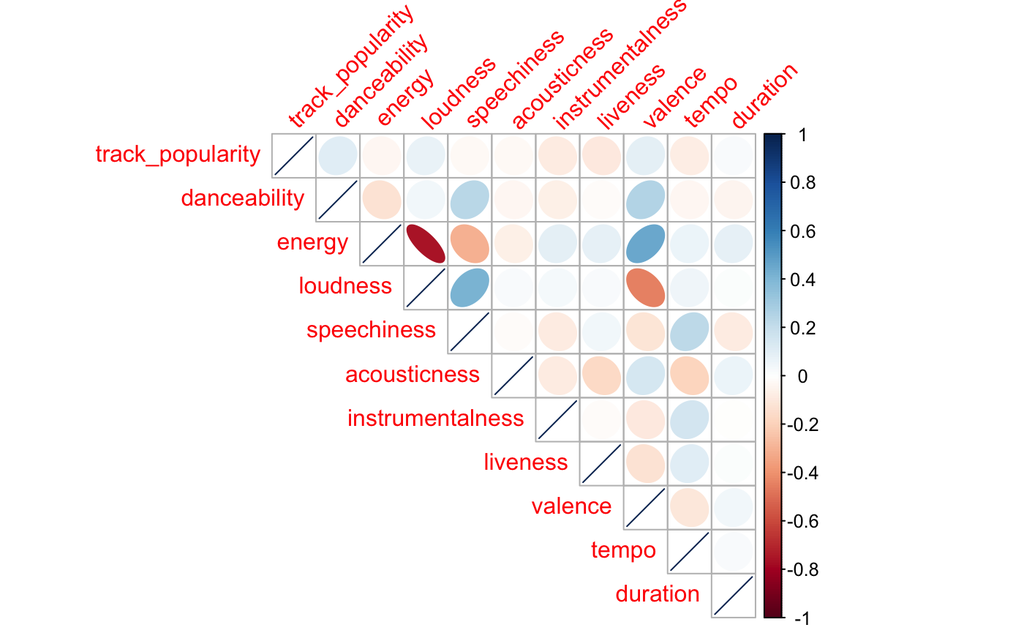

```r
library(corrplot)
cor <- cor(top2017numeric)
corrplot(cor, method= "ellipse", type = "upper", tl.srt = 45)
```

It looks like `speechiness` and `loudness` are positively correlated with each other.

Also, `valence` is positively correlated with `danceability` and `energy`. Considering happy songs make people energetic and want to dance, the correlation obviously makes sense.

Interestingly enough, `energy` and `loudness` are very negatively correlated.

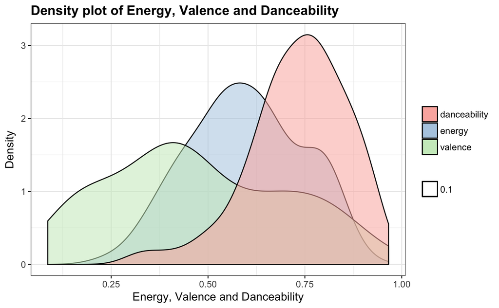

```r
ggplot(top2017) +
  geom_density(aes(energy, fill = "energy", alpha=0.1)) +
  geom_density(aes(valence, fill = "valence", alpha=0.1)) +
  geom_density(aes(danceability, fill = "danceability", alpha=0.1)) +
  scale_x_continuous(name = "Energy, Valence and Danceability") +
  scale_y_continuous(name = "Density") +
  ggtitle("Density plot of Energy, Valence and Danceability") +
  theme_bw() +
  theme(plot.title = element_text(size = 14, face = "bold"),
        text = element_text(size = 12)) +
  theme(legend.title = element_blank()) +
  scale_fill_brewer(palette = "Pastel1")
```

# Data Storage and Retrieval

## Data stored in a relational database (2 points)

```r
library(RMySQL)
# connect to to MySQL
db <- dbConnect(MySQL(), user = "username", password = "password", host = "localhost")
# make sure the connection is all set
summary(db)
```

```
<MySQLConnection:0,2>
  User:   username
  Host:   localhost
  Dbname:
  Connection type: Localhost via UNIX socket

Results:
```

```r
dbGetInfo(db)
```

```
$host
[1] "localhost"

$user
[1] "username"

$dbname
[1] ""

$conType
[1] "Localhost via UNIX socket"

$serverVersion
[1] "5.7.21"

$protocolVersion
[1] 10

$threadId
[1] 1784

$rsId
list()
```

```r
# create the database
dbSendQuery(db, "DROP DATABASE IF EXISTS top2017db;")
```

```
<MySQLResult:33661128,2,0>
```

```r
dbSendQuery(db, "CREATE DATABASE top2017db;")
```

```
<MySQLResult:238740528,2,1>
```

```r
# tell MySQL to use that database
dbSendQuery(db, "USE top2017db;")
```

```
<MySQLResult:238740360,2,2>
```

```r
# reconnect to the database just created
db <- dbConnect(MySQL(), user = "username", password = "password", host = "localhost", dbname = "top2017db")
```

## Multiple tables or objects in database (2 points)

```r
# clean up tables first
dbSendQuery(db, "DROP TABLE IF EXISTS top2017, top2017numeric")
```

```
<MySQLResult:238738368,3,0>
```

```r
# create a table for the top2017 dataframe
dbWriteTable(db, value = top2017, name = "top2017", overwrite=TRUE)
```

```
[1] TRUE
```

```r
# create a table for the dataframe containing numeric data
dbWriteTable(db, value = top2017numeric, name = "top2017numeric", overwrite=TRUE)
```

```
[1] TRUE
```

```r
# take a look to see that both tables have been added
dbListTables(db)
```

```
[1] "top2017"        "top2017numeric"
```

## Simple retrieval mechanism (5 points)

```r
# retrieve data from the database (will come back as a MySQLResult)
# and save the results of the query as a data frame
# The n parameter in the function specifies the number of records to retrieve, using n =-1 retrieves all pending records
res1 <- dbSendQuery(db, "SELECT * FROM top2017;")
data = fetch(res1, n = -1)
dbClearResult(res1)
```

```
[1] TRUE
```

```r
res2 <- dbSendQuery(db, "SELECT * FROM top2017numeric;")
data_num = fetch(res2, n = -1)
dbClearResult(res2)
```

```
[1] TRUE
```

## Complex joins or selective retrieval mechanism (8 points)

“Joining multiple tables and a filter (WHERE) is a complex join. A complex query would require subqueries, group by, aggregation, etc.”

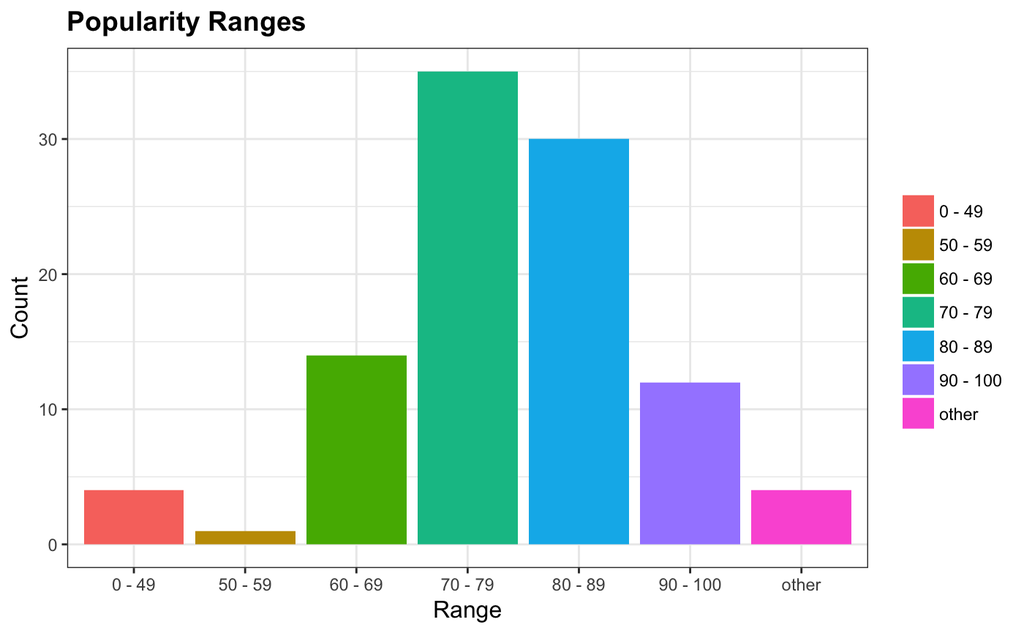

```r
pop <- dbSendQuery(db, "SELECT
                        CASE
                          WHEN track_popularity < 0.49 then '0 - 49'
                          WHEN track_popularity between 0.50 and 0.59 then '50 - 59'
                          WHEN track_popularity between 0.60 and 0.69 then '60 - 69'
                          WHEN track_popularity between 0.70 and 0.79 then '70 - 79'
                          WHEN track_popularity between 0.80 and 0.89 then '80 - 89'
                          WHEN track_popularity between 0.90 and 1 then '90 - 100'
                          ELSE 'other'
                        END as `range`, COUNT(*) as Count
                        FROM top2017
                        GROUP BY `range`;")
pop_data <- fetch(pop, n = -1)
ggplot(pop_data, aes(x = range, y = Count, fill = range)) +
  geom_bar(stat = "identity") +
  labs(title = "Popularity Ranges", x = "Range", y = "Count") +
  theme(plot.title = element_text(size = 14, face = "bold"), axis.title = element_text(size=12)) +
  theme(legend.title = element_blank())
```

```r
# group by mode
mode <- dbSendQuery(db, "SELECT COUNT(*) as Count, Mode
                         FROM top2017
                         GROUP BY mode;")
mode_data <- fetch(mode, n = -1)
mode_data
```

| Count | Mode |
| --- | --- |
| 59 | major |
| 41 | minor |

```r
# group by key mode
key_mode <- dbSendQuery(db, "SELECT COUNT(*) as Count, key_mode as KeyMode
                             FROM top2017
                             GROUP BY key_mode;")
key_mode_data <- fetch(key_mode, n = -1)
key_mode_data
```

| Count | KeyMode |
| --- | --- |
| 1 | A major |
| 3 | A minor |
| 3 | A# major |
| 3 | A# minor |
| 3 | B major |
| 10 | B minor |
| 8 | C major |
| 3 | C minor |
| 13 | C# major |
| 7 | C# minor |

[output cut: 12 more lines]

```r
# group by time signature
sig <- dbSendQuery(db, "SELECT COUNT(*) as Count, time_signature as TimeSignature
                             FROM top2017
                             GROUP BY time_signature;")
sig_data <- fetch(sig, n = -1)
sig_data
```

| Count | TimeSignature |
| --- | --- |
| 3 | 3 |
| 97 | 4 |

```r
# group by tempo marking
tempo <- dbSendQuery(db, "SELECT COUNT(*) as Count, tempo_marking as TempoMarking
                         FROM top2017
                         GROUP BY tempo_marking;")
tempo_data <- fetch(tempo, n = -1)
tempo_data
```

| Count | TempoMarking |
| --- | --- |
| 3 | adagio |
| 43 | allegro |
| 36 | andante |
| 8 | moderato |
| 4 | presto |
| 6 | vivace |

### Once all data is retrieved, close the connection to the MySQL database

```r
# function to kill DB Connections
killDbConnections <- lapply(dbListConnections(MySQL()), dbDisconnect)
```

```
Closing open result setsClosing open result sets
```

```r
killDbConnections
```

```
[[1]]
[1] TRUE

[[2]]
[1] TRUE
```

```r
on.exit(dbDisconnect(db))
```

# Model Construction and Evaluation

## Training & validation subsets (5 points)

```r
# 50% of the sample size
smp_size <- floor(0.5 * nrow(data))
# set the seed to make your partition reproducible
set.seed(123)
train_ind <- sample(seq_len(nrow(data)), size = smp_size)
# training data set
train_data <- data[train_ind, ]
# validation data set (all values not in the training data set)
test_data <- data[-train_ind, ]
# save off the test data track popularity column to use to check for the quality of the prediciton
test_pop <- test_data$track_popularity
```

## Multiple linear regression model (7 points)

Linear regression is one of the most widely known modeling techniques. It allows you, in short, to use a linear relationship to predict the (average) numerical value of Y for a given value of X with a straight line. This line is called the “regression line”.

As a consequence, the linear regression model is `y = ax + b`. The model assumes that the response variable `y` is quantitative.

### Predict the track popularity using all other numeric variables

```r
linear_model <- lm(formula = track_popularity ~ danceability + energy + loudness + speechiness + acousticness + liveness + valence + tempo + duration, data = train_data)
summary(linear_model)
```

```
Call:
lm(formula = track_popularity ~ danceability + energy + loudness +
    speechiness + acousticness + liveness + valence + tempo +
    duration, data = train_data)

Residuals:
     Min       1Q   Median       3Q      Max
-0.59447 -0.04452  0.01272  0.08807  0.28888

Coefficients:
              Estimate Std. Error t value Pr(>|t|)
(Intercept)   0.482832   0.255755   1.888   0.0663 .
danceability  0.198456   0.228048   0.870   0.3894
energy        0.161974   0.245155   0.661   0.5126
loudness      0.161165   0.161734   0.996   0.3250
speechiness   0.060537   0.225740   0.268   0.7899
acousticness -0.188222   0.157943  -1.192   0.2404
liveness      0.094634   0.292767   0.323   0.7482
valence      -0.003745   0.135743  -0.028   0.9781
tempo        -0.050361   0.102487  -0.491   0.6258
duration     -0.014028   0.154410  -0.091   0.9281
---
Signif. codes:  0 ‘***’ 0.001 ‘**’ 0.01 ‘*’ 0.05 ‘.’ 0.1 ‘ ’ 1

Residual standard error: 0.1607 on 40 degrees of freedom
Multiple R-squared:  0.09118,   Adjusted R-squared:  -0.1133
F-statistic: 0.4459 on 9 and 40 DF,  p-value: 0.9013
```

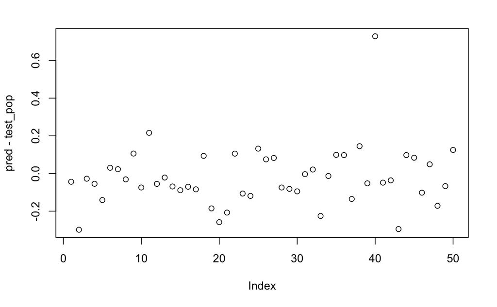

```r
pred <- predict(linear_model, test_data)
plot(pred - test_pop)
```

**Evaluation:** None of the p-values are significant (p < 0.05). R-squared and F-statistic are low (not significant)

```r
# https://stackoverflow.com/questions/5587676/pull-out-p-values-and-r-squared-from-a-linear-regression/35518814
# gets the model p-value
lmp <- function (modelobject) {
  if (class(modelobject) != "lm") stop("Not an object of class 'lm' ")
  f <- summary(modelobject)$fstatistic
  p <- pf(f[1],f[2],f[3],lower.tail=F)
  attributes(p) <- NULL
  return(p)
}
cat("p-value: ", lmp(linear_model))
```

```
p-value:  0.9013192
```

Make a forwards fitting prediction with the model above

```r
prediction <- predict(linear_model, data.frame(danceability = 0.9, energy = 0.8, loudness = 0.4, speechiness = 0.1, acousticness = 0.1, liveness = 0.1, valence = 0.5, tempo = 0.7, duration = 0.6))
cat("Prediction of track popularity: ", prediction)
```

```
Prediction of track popularity:  0.806641
```

Backwards fitting

```r
prediction <- predict(linear_model, data.frame(danceability = 0.1, energy = 0.2, loudness = 0.9, speechiness = 0.8, acousticness = 0.9, liveness = 0.8, valence = 0.1, tempo = 0.95, duration = 0.98))
cat("Prediction of track popularity: ", prediction)
```

```
Prediction of track popularity:  0.5728932
```

### Predict the track popularity using danceability, speechiness, acousticness, and liveness

```r
linear_model <- lm(formula = track_popularity ~ danceability + speechiness + acousticness + liveness, data = train_data)
summary(linear_model)
```

```
Call:
lm(formula = track_popularity ~ danceability + speechiness +
    acousticness + liveness, data = train_data)

Residuals:
     Min       1Q   Median       3Q      Max
-0.61859 -0.05648  0.02003  0.09388  0.25435

Coefficients:
             Estimate Std. Error t value Pr(>|t|)
(Intercept)    0.5941     0.1545   3.845 0.000377 ***
danceability   0.2039     0.1997   1.021 0.312519
speechiness    0.1091     0.1830   0.596 0.554284
acousticness  -0.1545     0.1470  -1.051 0.298739
liveness       0.1361     0.2735   0.498 0.621180
---
Signif. codes:  0 ‘***’ 0.001 ‘**’ 0.01 ‘*’ 0.05 ‘.’ 0.1 ‘ ’ 1

Residual standard error: 0.154 on 45 degrees of freedom
Multiple R-squared:  0.06093,   Adjusted R-squared:  -0.02255
F-statistic: 0.7299 on 4 and 45 DF,  p-value: 0.5763
```

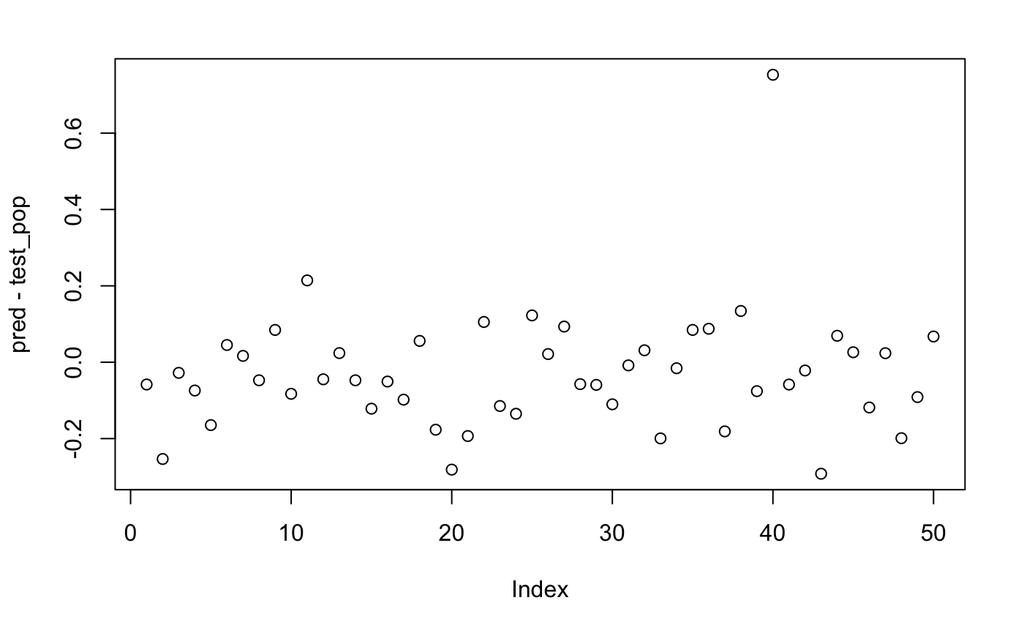

```r
pred <- predict(linear_model, test_data)
plot(pred - test_pop)
```

**Evaluation:** None of the p-values are significant. R squared is low. F-statistic is okay (0.7299).

```r
cat("p-value: ", lmp(linear_model))
```

```
p-value:  0.5763051
```

Make a forwards fitting prediction with the model above

```r
prediction <- predict(linear_model, data.frame(danceability = 0.9, speechiness = 0.1, acousticness = 0.1, liveness = 0.1))
cat("Prediction of track popularity: ", prediction)
```

```
Prediction of track popularity:  0.7866972
```

Backwards fitting

```r
prediction <- predict(linear_model, data.frame(danceability = 0.1, speechiness = 0.8, acousticness = 0.8, liveness = 0.8))
cat("Prediction of track popularity: ", prediction)
```

```
Prediction of track popularity:  0.6869936
```

## Logistic regression model (7 points)

Logistic regression is an instance of classification technique that you can use to predict a qualitative response.

```r
logistic_model <- glm(formula = track_popularity ~ danceability + energy + loudness + speechiness + acousticness + liveness + valence + tempo + duration, data = train_data, family = binomial(link='logit'))
```

```
non-integer #successes in a binomial glm!
```

```r
summary(logistic_model)
```

```
Call:
glm(formula = track_popularity ~ danceability + energy + loudness +
    speechiness + acousticness + liveness + valence + tempo +
    duration, family = binomial(link = "logit"), data = train_data)

Deviance Residuals:
     Min        1Q    Median        3Q       Max
-1.24579  -0.10637   0.03053   0.22155   0.71687

Coefficients:
             Estimate Std. Error z value Pr(>|z|)
(Intercept)  -0.31709    3.70707  -0.086    0.932
danceability  1.08970    3.35699   0.325    0.745
energy        0.84182    3.53550   0.238    0.812
loudness      0.84685    2.35405   0.360    0.719
speechiness   0.36286    3.35875   0.108    0.914
acousticness -0.99215    2.24138  -0.443    0.658
liveness      0.55159    4.39955   0.125    0.900
valence      -0.04194    2.00999  -0.021    0.983
tempo        -0.28405    1.51021  -0.188    0.851
duration     -0.06644    2.25158  -0.030    0.976

(Dispersion parameter for binomial family taken to be 1)

    Null deviance: 5.7951  on 49  degrees of freedom
Residual deviance: 5.2369  on 40  degrees of freedom
AIC: 54.257

Number of Fisher Scoring iterations: 4
```

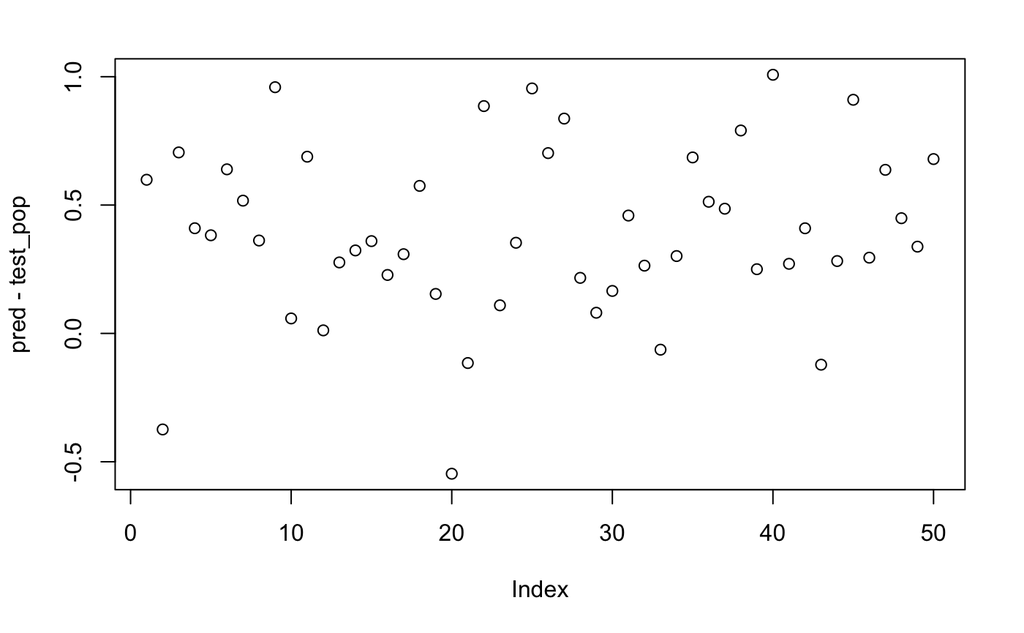

```r
pred <- predict(logistic_model, test_data)
plot(pred - test_pop)
```

Analyze the table of deviance

```r
anova(logistic_model, test="Chisq")
```

[output not shown]

```
Analysis of Deviance Table

Model: binomial, link: logit

Response: track_popularity

Terms added sequentially (first to last)

             Df Deviance Resid. Df Resid. Dev Pr(>Chi)
NULL                            49     5.7951
danceability  1 0.141268        48     5.6538   0.7070
energy        1 0.009004        47     5.6448   0.9244
loudness      1 0.167649        46     5.4772   0.6822
speechiness   1 0.010028        45     5.4671   0.9202
acousticness  1 0.177996        44     5.2891   0.6731
liveness      1 0.016138        43     5.2730   0.8989
valence       1 0.000074        42     5.2729   0.9931
tempo         1 0.035175        41     5.2378   0.8512
duration      1 0.000871        40     5.2369   0.9765
```

**Evaluation:** None of the p-values are significant.

Make a forwards fitting prediction with the model above

```r
prediction <- predict(logistic_model, data.frame(danceability = 0.9, energy = 0.8, loudness = 0.4, speechiness = 0.1, acousticness = 0.1, liveness = 0.1, valence = 0.5, tempo = 0.7, duration = 0.6))
cat("Prediction of track popularity: ", prediction)
```

```
Prediction of track popularity:  1.408385
```

Backwards fitting

```r
prediction <- predict(logistic_model, data.frame(danceability = 0.1, energy = 0.2, loudness = 0.9, speechiness = 0.8, acousticness = 0.9, liveness = 0.8, valence = 0.1, tempo = 0.95, duration = 0.98))
cat("Prediction of track popularity: ", prediction)
```

```
Prediction of track popularity:  0.2218707
```

### Predict the track popularity using danceability, speechiness, acousticness, and liveness

```r
logistic_model <- glm(formula = track_popularity ~ danceability + speechiness + acousticness + liveness, data = train_data, family = binomial(link='logit'))
```

```
non-integer #successes in a binomial glm!
```

```r
summary(logistic_model)
```

```
Call:
glm(formula = track_popularity ~ danceability + speechiness +
    acousticness + liveness, family = binomial(link = "logit"),
    data = train_data)

Deviance Residuals:
     Min        1Q    Median        3Q       Max
-1.30299  -0.12511   0.05036   0.22856   0.64399

Coefficients:
             Estimate Std. Error z value Pr(>|z|)
(Intercept)    0.2424     2.3332   0.104    0.917
danceability   1.1174     3.0235   0.370    0.712
speechiness    0.6146     2.8706   0.214    0.830
acousticness  -0.8181     2.1649  -0.378    0.706
liveness       0.7777     4.2324   0.184    0.854

(Dispersion parameter for binomial family taken to be 1)

    Null deviance: 5.7951  on 49  degrees of freedom
Residual deviance: 5.4194  on 45  degrees of freedom
AIC: 44.473

Number of Fisher Scoring iterations: 4
```

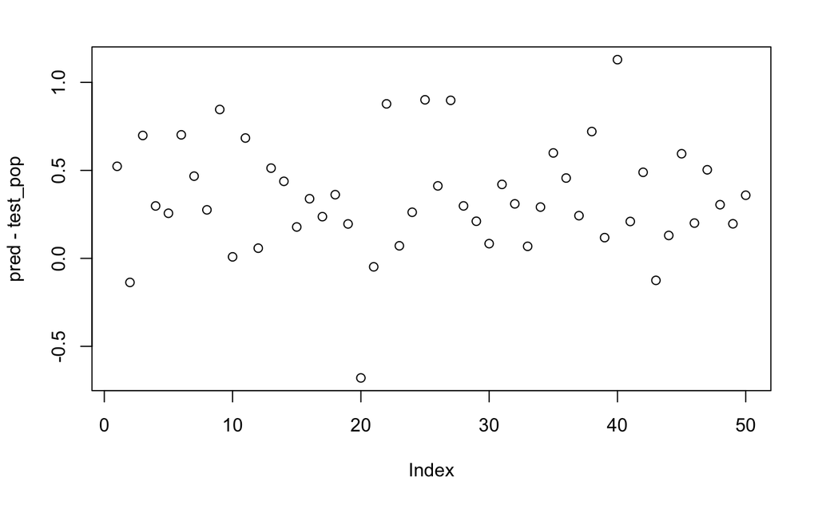

```r
pred <- predict(logistic_model, test_data)
plot(pred - test_pop)
```

Analyze the table of deviance

```r
anova(logistic_model, test="Chisq")
```

```
non-integer #successes in a binomial glm!non-integer #successes in a binomial glm!non-integer #successes in a binomial glm!
```

```
Analysis of Deviance Table

Model: binomial, link: logit

Response: track_popularity

Terms added sequentially (first to last)

             Df Deviance Resid. Df Resid. Dev Pr(>Chi)
NULL                            49     5.7951
danceability  1 0.141268        48     5.6538   0.7070
speechiness   1 0.043773        47     5.6100   0.8343
acousticness  1 0.156397        46     5.4537   0.6925
liveness      1 0.034229        45     5.4194   0.8532
```

**Evaluation:** None of the p-values are significant.

Make a forwards fitting prediction with the model above

```r
prediction <- predict(logistic_model, data.frame(danceability = 0.9, speechiness = 0.1, acousticness = 0.1, liveness = 0.1))
cat("Prediction of track popularity: ", prediction)
```

```
Prediction of track popularity:  1.305455
```

Backwards fitting

```r
prediction <- predict(logistic_model, data.frame(danceability = 0.1, speechiness = 0.8, acousticness = 0.8, liveness = 0.8))
cat("Prediction of track popularity: ", prediction)
```

```
Prediction of track popularity:  0.8135493
```

## Recursive Partitioning and Regression Trees (Other, 5 points)

```r
library(rpart)
rpart_model <- rpart(formula = track_popularity ~ danceability + energy + loudness + speechiness + acousticness + liveness + valence + tempo + duration, data = train_data, method = "anova")
# detailed results including surrogate splits
summary(rpart_model)
```

```
Call:
rpart(formula = track_popularity ~ danceability + energy + loudness +
    speechiness + acousticness + liveness + valence + tempo +
    duration, data = train_data, method = "anova")
  n= 50

          CP nsplit rel error   xerror      xstd
1 0.08593665      0 1.0000000 1.022881 0.4235253
2 0.03021269      2 0.8281267 1.363615 0.5116921
3 0.01000000      3 0.7979140 1.425247 0.5142689

Variable importance
     valence danceability       energy     loudness     duration  speechiness        tempo     liveness acousticness
          29           19           17            9            8            8            6            2            1

Node number 1: 50 observations,    complexity param=0.08593665
  mean=0.7536842, MSE=0.02273881
  left son=2 (32 obs) right son=3 (18 obs)
  Primary splits:
      danceability < 0.771     to the left,  improve=0.07036427, (0 missing)
      acousticness < 0.1245    to the right, improve=0.06374767, (0 missing)
      valence      < 0.7475    to the left,  improve=0.06228311, (0 missing)
      loudness     < 0.2654749 to the left,  improve=0.05913862, (0 missing)
      liveness     < 0.096     to the right, improve=0.04626707, (0 missing)
  Surrogate splits:
      energy   < 0.4465    to the right, agree=0.68, adj=0.111, (0 split)
      liveness < 0.07185   to the right, agree=0.68, adj=0.111, (0 split)
      duration < 0.2589286 to the right, agree=0.68, adj=0.111, (0 split)
      loudness < 0.5189385 to the left,  agree=0.66, adj=0.056, (0 split)
      valence  < 0.8365    to the left,  agree=0.66, adj=0.056, (0 split)

Node number 2: 32 observations,    complexity param=0.08593665
  mean=0.7236842, MSE=0.0294129
  left son=4 (9 obs) right son=5 (23 obs)
  Primary splits:
      valence      < 0.5365    to the right, improve=0.12261810, (0 missing)
      loudness     < 0.4006704 to the left,  improve=0.11636210, (0 missing)
      speechiness  < 0.1335    to the left,  improve=0.07870068, (0 missing)
      danceability < 0.672     to the right, improve=0.06037393, (0 missing)
      tempo        < 0.2088695 to the right, improve=0.05758239, (0 missing)
```

[output cut: 17 more lines]

```
      acousticness < 0.226     to the left,  improve=0.12285640, (0 missing)
      loudness     < 0.2689944 to the left,  improve=0.10323350, (0 missing)
      tempo        < 0.2441603 to the right, improve=0.07038706, (0 missing)
      duration     < 0.3995536 to the right, improve=0.06146477, (0 missing)
  Surrogate splits:
      energy       < 0.778     to the right, agree=0.783, adj=0.375, (0 split)
      loudness     < 0.2689944 to the left,  agree=0.739, adj=0.250, (0 split)
      acousticness < 0.414     to the right, agree=0.696, adj=0.125, (0 split)
      valence      < 0.501     to the right, agree=0.696, adj=0.125, (0 split)

Node number 10: 8 observations
  mean=0.7083333, MSE=0.008151547

Node number 11: 15 observations
  mean=0.7894737, MSE=0.007304812
```

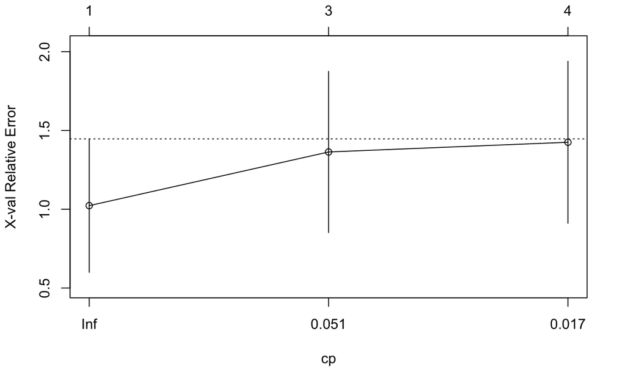

```r
pred <- predict(rpart_model, test_data)
# plot cross-validation results
plotcp(rpart_model)
```

```
Regression tree:
rpart(formula = track_popularity ~ danceability + energy + loudness +
    speechiness + acousticness + liveness + valence + tempo +
    duration, data = train_data, method = "anova")

Variables actually used in tree construction:
[1] danceability speechiness  valence

Root node error: 1.1369/50 = 0.022739

n= 50

        CP nsplit rel error xerror    xstd
1 0.085937      0   1.00000 1.0229 0.42353
2 0.030213      2   0.82813 1.3636 0.51169
3 0.010000      3   0.79791 1.4252 0.51427
```

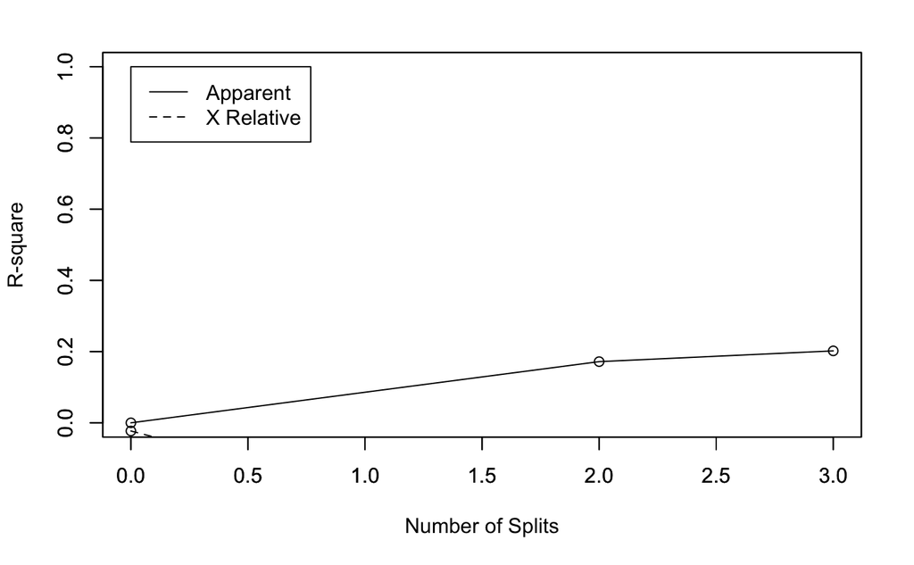

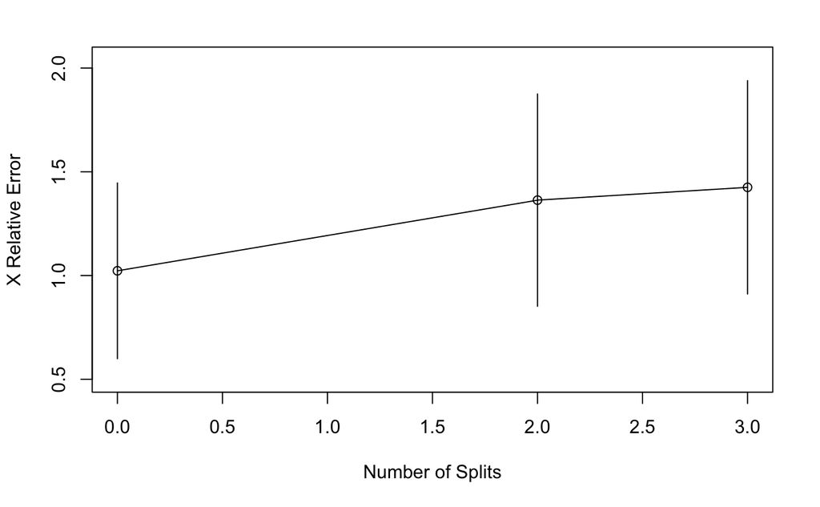

```r
# plot approximate R-squared and relative error for different splits (2 plots). labels are only appropriate for the "anova" method.
rsq.rpart(rpart_model)
```

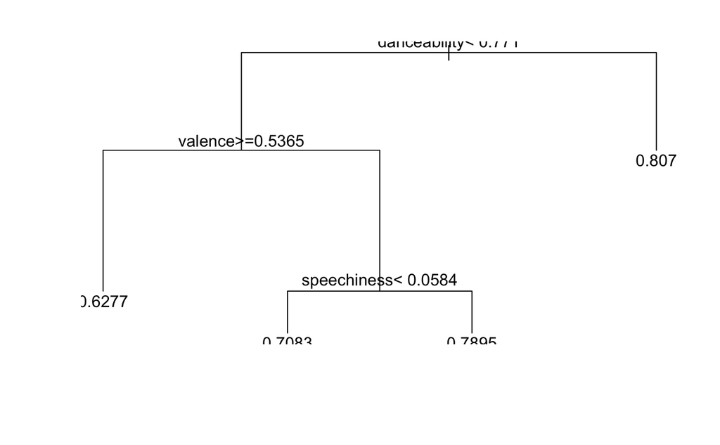

```r
# plot decision tree
plot(rpart_model)
text(rpart_model)
```

**Evaluation:** None of the p-values are significant.

Make a forwards fitting prediction with the model above

```r
prediction <- predict(rpart_model, data.frame(danceability = 0.9, energy = 0.8, loudness = 0.4, speechiness = 0.1, acousticness = 0.1, liveness = 0.1, valence = 0.5, tempo = 0.7, duration = 0.6))
cat("Prediction of track popularity: ", prediction)
```

```
Prediction of track popularity:  0.8070175
```

Backwards fitting

```r
prediction <- predict(rpart_model, data.frame(danceability = 0.1, energy = 0.2, loudness = 0.9, speechiness = 0.8, acousticness = 0.9, liveness = 0.8, valence = 0.1, tempo = 0.95, duration = 0.98))
cat("Prediction of track popularity: ", prediction)
```

```
Prediction of track popularity:  0.7894737
```

### Predict the track popularity using danceability, speechiness, acousticness, and liveness

```r
rpart_model <- rpart(formula = track_popularity ~ danceability + speechiness + acousticness + liveness, data = train_data, method = "anova")
# detailed results including surrogate splits
summary(rpart_model)
```

```
Call:
rpart(formula = track_popularity ~ danceability + speechiness +
    acousticness + liveness, data = train_data, method = "anova")
  n= 50

          CP nsplit rel error   xerror      xstd
1 0.08104199      0  1.000000 1.017877 0.4212065
2 0.01000000      3  0.756874 1.286444 0.4217819

Variable importance
danceability  speechiness acousticness     liveness
          53           25           11           11

Node number 1: 50 observations,    complexity param=0.08104199
  mean=0.7536842, MSE=0.02273881
  left son=2 (32 obs) right son=3 (18 obs)
  Primary splits:
      danceability < 0.771    to the left,  improve=0.07036427, (0 missing)
      acousticness < 0.1245   to the right, improve=0.06374767, (0 missing)
      liveness     < 0.096    to the right, improve=0.04626707, (0 missing)
      speechiness  < 0.228    to the left,  improve=0.04189691, (0 missing)
  Surrogate splits:
      liveness < 0.07185  to the right, agree=0.68, adj=0.111, (0 split)

Node number 2: 32 observations,    complexity param=0.08104199
  mean=0.7236842, MSE=0.0294129
  left son=4 (24 obs) right son=5 (8 obs)
  Primary splits:
      speechiness  < 0.1335   to the left,  improve=0.07870068, (0 missing)
      danceability < 0.672    to the right, improve=0.06037393, (0 missing)
      liveness     < 0.0993   to the right, improve=0.04772120, (0 missing)
      acousticness < 0.05995  to the right, improve=0.04474207, (0 missing)
  Surrogate splits:
      acousticness < 0.005765 to the right, agree=0.781, adj=0.125, (0 split)

Node number 3: 18 observations
  mean=0.8070175, MSE=0.006429329

Node number 4: 24 observations,    complexity param=0.08104199
  mean=0.6959064, MSE=0.03433535
  left son=8 (13 obs) right son=9 (11 obs)
  Primary splits:
      danceability < 0.672    to the right, improve=0.14846910, (0 missing)
      liveness     < 0.1855   to the left,  improve=0.06931099, (0 missing)
      speechiness  < 0.0564   to the left,  improve=0.03005834, (0 missing)
      acousticness < 0.1245   to the right, improve=0.02942774, (0 missing)
  Surrogate splits:
      acousticness < 0.05875  to the right, agree=0.667, adj=0.273, (0 split)
      liveness     < 0.0894   to the right, agree=0.667, adj=0.273, (0 split)
      speechiness  < 0.1037   to the right, agree=0.625, adj=0.182, (0 split)

Node number 5: 8 observations
  mean=0.8070175, MSE=0.005386273

Node number 8: 13 observations
  mean=0.6302294, MSE=0.04519552

Node number 9: 11 observations
  mean=0.7735247, MSE=0.01037827
```

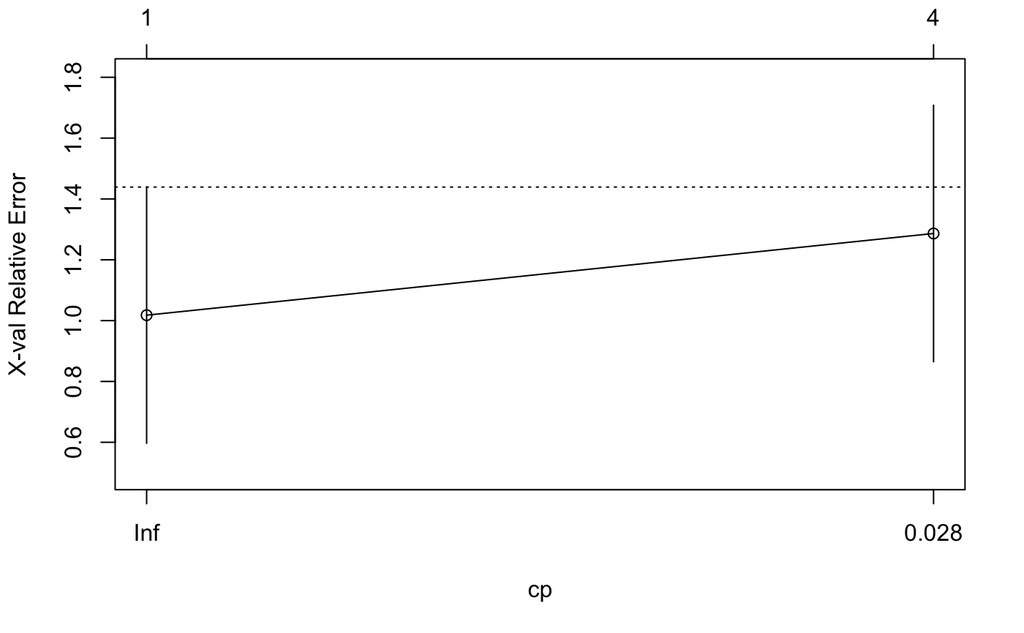

```r
pred <- predict(rpart_model, test_data)
# plot cross-validation results
plotcp(rpart_model)
```

```
Regression tree:
rpart(formula = track_popularity ~ danceability + speechiness +
    acousticness + liveness, data = train_data, method = "anova")

Variables actually used in tree construction:
[1] danceability speechiness

Root node error: 1.1369/50 = 0.022739

n= 50

        CP nsplit rel error xerror    xstd
1 0.081042      0   1.00000 1.0179 0.42121
2 0.010000      3   0.75687 1.2864 0.42178
```

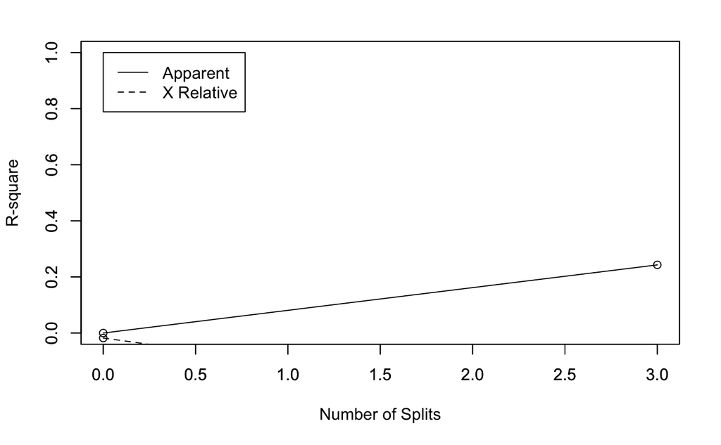

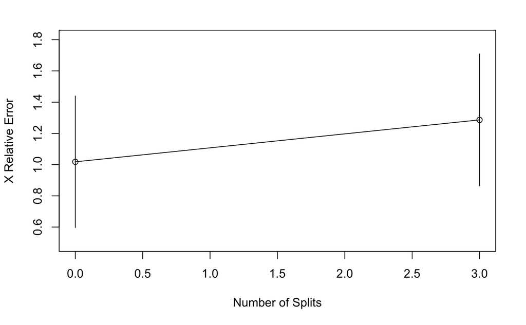

```r
# plot approximate R-squared and relative error for different splits (2 plots). labels are only appropriate for the "anova" method.
rsq.rpart(rpart_model)
```

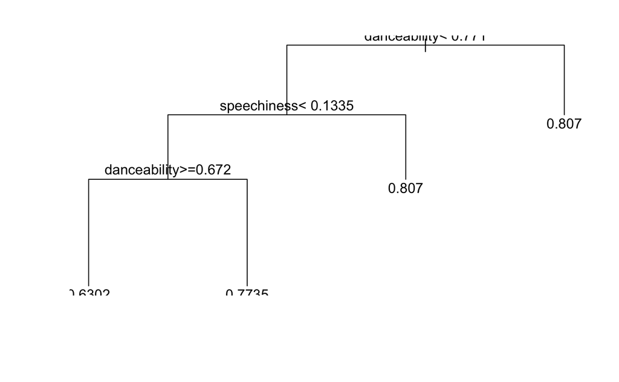

```r
# plot decision tree
plot(rpart_model)
text(rpart_model)
```

**Evaluation:** None of the p-values are significant.

Make a forwards fitting prediction with the model above

```r
prediction <- predict(rpart_model, data.frame(danceability = 0.9, speechiness = 0.1, acousticness = 0.1, liveness = 0.1))
cat("Prediction of track popularity: ", prediction)
```

```
Prediction of track popularity:  0.8070175
```

Backwards fitting

```r
prediction <- predict(rpart_model, data.frame(danceability = 0.1, speechiness = 0.8, acousticness = 0.8, liveness = 0.8))
cat("Prediction of track popularity: ", prediction)
```

```
Prediction of track popularity:  0.8070175
```

## Evaluation of fit of model (5 points) & Comparison of models (5 points) & Interpretation of results/prediction with interval (5 points)

None of the models constructed above had p-values that were significant (p < 0.05). For each type of model, constructed two models and two predictions for each (four predictions per type of model).

The first model included nearly all of the numeric audio features of the tracks:

```
track_popularity ~ danceability + energy + loudness + speechiness + acousticness + liveness + valence + tempo + duration
```

The second model only included danceability, speechiness, acousticness, and liveness as the dependent variables.

```
track_popularity ~ danceability + speechiness + acousticness + liveness
```

For both models of each model type, I conducted forward fitting and backwards fitting predictions. Basically, for the forward fitting predictions, I plugged in values that I thought would make the track popular (high danceability, low acousticness, low liveness, etc.). For the backwards fitting predictions, I plugged in values that I thought would make the track less popular (low danceability, high speechiness, etc.). These values were just estimations based on the data understanding and data preparation steps conducted before the model construction & evaluation section.

Overall, none of the models constructed were statistically significant (p < 0.05), but the model that was closest to being significant was the second multiple linear regression model based on the `danceability`, `speechiness`, `acousticness`, and `liveness` variables. The p-value of this model was 0.57.

Link to my slide deck: https://docs.google.com/presentation/d/1Cl4MDQ4sT5aexGMreKPJFxeU_wHigYcV2NknR8Zg3fQ/edit?usp=sharing